# Lab 7

- Show All Code
- Hide All Code
- View Source

Author

Kailyn Kragas

## Packages & Dataset

```r
library(tidyverse)
fishData <- read_csv(here::here("Labs",
                                "Lab 7",
                                "BlackfootFish.csv"))
```

## **2.1 Summarizing Missing Data**

- Our data set with 7 variables has a complete set of observations except for the *weight* column with 1796 missing data.

```r
fishData |> summarise(across(.cols = everything(),
                             .fns = ~ sum(is.na(.))))
```

```
# A tibble: 1 × 7
   trip  mark length weight  year section species
  <int> <int>  <int>  <int> <int>   <int>   <int>
1     0     0      0   1796     0       0       0
```

## **2.2 Visualizing Missing Data**

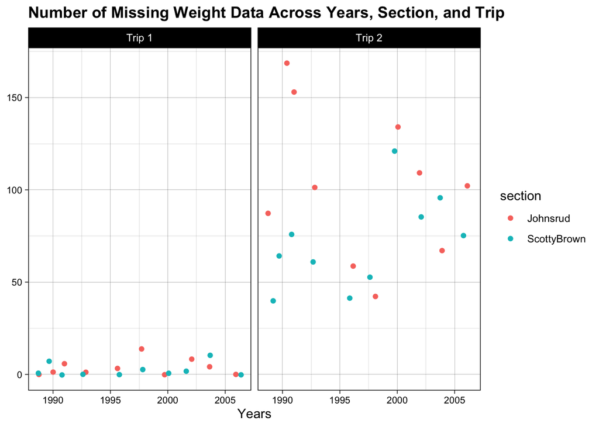

```r
fishData |>
  group_by(year, section, trip) |>
  summarise(naWeight = sum(is.na(weight))) |>
  mutate(trip = case_when(trip == 1 ~ "Trip 1", TRUE ~ "Trip 2")) |>
  ggplot(mapping = aes(x = year,
                       y = naWeight,
                       color = section)) +
  geom_jitter() +
  facet_wrap(~trip) +
  theme_linedraw() +
  labs(title = "Number of Missing Weight Data Across Years, Section, and Trip",
       x = "Years",
       fill = "Section") +
  theme(axis.title.y = element_blank(),
        plot.title = element_text(face = "bold"),
        axis.text = element_text(size = 8))
```

## **3.1 Writing a Function**

```r
rescale_01 <- function(x) {

  min <- min(x, na.rm = TRUE)
  max <- max(x, na.rm = TRUE)

  new <- (x - min) /
         (max - min)

  return(new)

}
```

## **3.2 Adding Stops**

```r
rescale_01 <- function(x) {

  stopifnot(is.numeric(x), length(x) > 1)

  min <- min(x, na.rm = TRUE)
  max <- max(x, na.rm = TRUE)

  new <- (x - min) /
         (max - min)

  return(new)
}
```

## **3.3 Performing a Simple Test**

```r
x <- c(1:85)
rescaled <- rescale_01(x)
min(rescaled)
```

```
[1] 0
```

```r
max(rescaled)
```

```
[1] 1
```

## **3.4 Performing a More Difficult Test**

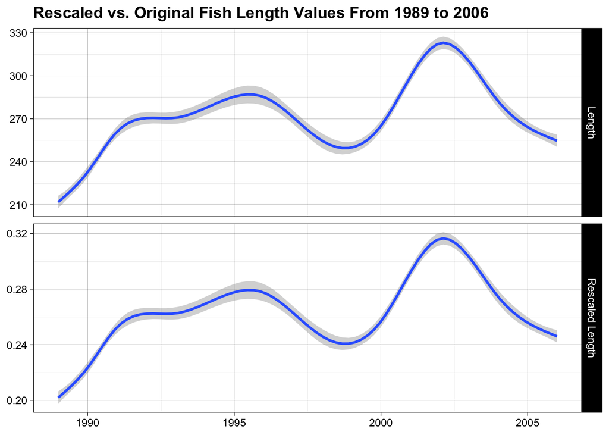

```r
# https://stats.stackexchange.com/questions/1838/how-do-i-vertically-stack-two-graphs-with-the-same-x-scale-but-a-different-y-sc
plusRescale <- fishData |> mutate(`Rescaled Length` = rescale_01(length)) |>
  rename(Length = length)

plusRescale |> pivot_longer(cols = c(Length, `Rescaled Length`),
               names_to = "Type",
               values_to = "Length") |>
  ggplot(mapping = aes(x = year, y = Length)) +
  geom_smooth() +
  facet_grid(Type ~ ., scales="free") +
  labs(title = "Rescaled vs. Original Fish Length Values From 1989 to 2006") +
  theme_linedraw() +
  theme(axis.title.y = element_blank(),
        axis.title.x = element_blank(),
        plot.title = element_text(face = "bold"))
```

## **3.5 Incorportaing Variables**

```r
rescale_column <- function(df, var) {

  stopifnot(is.data.frame(df))

  newDF <- df |> mutate(across(.col = {{var}},
                               .fns = ~ rescale_01(.)))

  return(newDF)
}
```

## **3.6 Another Function Test**

```r
rescaledData <- fishData |> rescale_column(c(length, weight))
```

## Reflection:

My initial function in Part 1 has a superseded lifecycle which means that it is not maintained anymore. When using functions in R, it is helpful to check the help file to see its life cycle and use the alternative if the initial function being used is superseded. Similar to this is the usage of the across function. It is good to start using the more recent version rather than the plain old across function. Another thing I learned is that even if we are plotting years, it is not always valid to use a geom_line() especially if there is no continuous relationship between the years. I have changed my graph in Q2 to scatter plot to display a quantitative relationship across multiple factors. Lastly, when dealing with functions, specifically repeating lines of code, it is more efficient to store the line of code in a variable to avoid calling the same function multiple times. The initial function I made was an efficient way to calculate for a vlaue, however the structure of the function was inefficient. Within the function, I was using min() and max() multiple times when I could have just stored them in their own separate variables to reduce calling. After receiving feedback, I will most certainly take them into account for my future assignments as well.